# Comment les pesticides influencent-ils le chiffre d’affaires des agriculteurs ?

Valentin Lamy · Faresse Bouchemella · Rémi Moriceau · Enzo Combe — Groupe C

03 octobre 2026

```r
library(tidyverse)
library(readr)
library(ggplot2)
library(corrplot)
library(kableExtra)
library(scales)
library(broom)
library(gridExtra)
library(lmtest)
library(sandwich)
```

# Importation des données

## Importation Rica

```r
Rica <- read_delim( "data/Rica_France_micro_Donnees_ex2023.csv",
  delim = ";",
  locale = locale(
    decimal_mark = ".",
    grouping_mark = ",",
    encoding = "UTF-8"
  ),
  escape_double = FALSE,
  trim_ws = TRUE,
  show_col_types = FALSE,
  guess_max = 5000
)

cat("Dimensions :", nrow(Rica), "exploitations,", ncol(Rica), "variables\n")
```

```
## Dimensions : 7220 exploitations, 986 variables
```

```r
cat("Année      :", unique(Rica$MILEX), "\n")
```

```
## Année      : 2023
```

## Importation Region

```r
region <- read_csv("data/region.csv",
  locale = locale(encoding = "latin1"),
  show_col_types = FALSE
)

colnames(region) <- c("ANNEE","NOM_REGION","CODE_REGION","NOM_DEPT",
                       "CODE_DEPT","AMM","NOM_PRODUIT","EAJ",
                       "BIOCONTROLE","UAB","ACHAT_ETRANGER","SUBSTANCE",
                       "NUMERO_CAS","FONCTION","DANGER","QUANTITE")

region <- region %>%
  filter(ANNEE != "ANNEE") %>%
  mutate(
    ANNEE    = as.integer(ANNEE),
    QUANTITE = as.numeric(QUANTITE),
    FONCTION_clean = case_when(
      str_detect(FONCTION, "(?i)herbicide")   ~ "Herbicides",
      str_detect(FONCTION, "(?i)fongicide")   ~ "Fongicides",
      str_detect(FONCTION, "(?i)insecticide") ~ "Insecticides",
      TRUE ~ "Autres"
    )
  )
cat("Dimensions :", nrow(region), "lignes,", ncol(region), "colonnes\n")
```

```
## Dimensions : 1048574 lignes, 17 colonnes
```

```r
cat("Période    :", min(region$ANNEE, na.rm=TRUE), "–",
                    max(region$ANNEE, na.rm=TRUE), "\n")
```

```
## Période    : 2013 – 2023
```

```r
cat("Substances :", n_distinct(region$SUBSTANCE), "distinctes\n")
```

```
## Substances : 545 distinctes
```

```r
cat("Régions    :", n_distinct(region$NOM_REGION), "\n")
```

```
## Régions    : 19
```

```r
cat("Depts      :", n_distinct(region$NOM_DEPT), "\n")
```

```
## Depts      : 102
```

# Introduction

## Problématique

Comment les dépenses en produits phytosanitaires influencent-elles le chiffre d’affaires des exploitations agricoles françaises ?

## Équation idéale

L’équation idéale, si toutes les données étaient disponibles, s’écrirait :

$$\ln(CA_i) = \alpha_0
+ \beta_1 \ln(Phytosanitaires_i)
+ \beta_2 \ln(Surface_i)
+ \beta_3 \ln(Travail_i)
+ \beta_4 \ln(Engrais_i)
+ \beta_5 \ln(Capital_i)
+ \beta_6 Prix\_produits_i
+ \sum_j \gamma_j \cdot Region_{ij}
+ \varepsilon_i$$
## Équation

$$\ln(CA_i) = \alpha_0
+ \beta_1 \ln(Phytosanitaires_i)
+ \beta_2 \ln(Surface_i)
+ \beta_3 \ln(Travail_i)
+ \beta_4 \ln(Engrais_i)
+ \beta_5 \ln(Subventions_i)
+ \varepsilon_i$$

# Définition clé primaire

## Clé primaire RICA

La clé primaire est **`IDNUM`** : identifiant numérique unique par exploitation.

```r
cat("Nombre de lignes          :", nrow(Rica), "\n")
```

```
## Nombre de lignes          : 7220
```

```r
cat("Valeurs uniques de IDNUM  :", n_distinct(Rica$IDNUM), "\n")
```

```
## Valeurs uniques de IDNUM  : 7220
```

```r
cat("=> Clé primaire valide    :", nrow(Rica) == n_distinct(Rica$IDNUM), "\n")
```

```
## => Clé primaire valide    : TRUE
```

# Dictionnaire des variables

## RICA

Dictionnaire des variables RICA retenues

| Variable | Nature | Description | Unite |
| --- | --- | --- | --- |
| IDNUM | Quant. discrète | Identifiant unique de l’exploitation — CLÉ PRIMAIRE | — |
| MILEX | Quant. discrète | Millésime de l’exercice comptable (2023) | année |
| REGIO | Qual. nominale | Code région RICA — variable de fusion avec BNV-D | code |
| OTE64F | Qual. nominale | Orientation technico-économique (type de production) | code |
| CHAFF | Quant. continue | Chiffre d’affaires total — VARIABLE DÉPENDANTE | € |
| ACHPH | Quant. continue | Achats de produits phytosanitaires — VARIABLE D’INTÉRÊT | € |
| SUTOT | Quant. continue | Surface agricole utilisée totale | ha |
| UTANS | Quant. continue | Main-d’œuvre totale en Unités de Travail Annuel | UTH |
| CHRGTO | Quant. continue | Charges totales de l’exploitation | € |
| SUBEX | Quant. continue | Subventions d’exploitation (aides PAC) | € |
| CHREN | Quant. continue | Charges en engrais et amendements minéraux | € |
| CHRSE | Quant. continue | Charges en semences et plants | € |

## Region

Dictionnaire des variables BNV-D

| Variable | Nature | Description | Unite |
| --- | --- | --- | --- |
| ANNEE | Quant. discrète | Année de vente — PARTIE CLÉ COMPOSITE | année |
| NOM_REGION | Qual. nominale | Nom de la région de l’acheteur | — |
| CODE_REGION | Qual. nominale | Code INSEE région — variable de fusion avec RICA | code |
| NOM_DEPT | Qual. nominale | Nom du département | — |
| CODE_DEPT | Qual. nominale | Code du département — PARTIE CLÉ | code |
| AMM | Qual. nominale | N° AMM — PARTIE CLÉ | — |
| NOM_PRODUIT | Qual. nominale | Nom commercial du produit | — |
| EAJ | Qual. binaire | Substance classée Endocrinien Avéré/suspecté | oui/non |
| BIOCONTROLE | Qual. binaire | Substance de biocontrôle | oui/non |
| UAB | Qual. binaire | Autorisée en agriculture biologique | uab/non |
| ACHAT_ETRANGER | Qual. binaire | Achat à l’étranger | oui/non |
| SUBSTANCE | Qual. nominale | Substance active — PARTIE CLÉ | — |
| NUMERO_CAS | Qual. nominale | Numéro CAS | — |
| FONCTION | Qual. nominale | Herbicide / Fongicide / Insecticide / Autres | — |
| DANGER | Qual. nominale | Niveau de danger | — |
| QUANTITE | Quant. continue | Quantité vendue — VARIABLE PRINCIPALE | kg |

# Fusion des tables

Variable instrumentale : pour Rica : REGIO et pour Region : CODE_REGION

```r
Rica_clean <- Rica %>%
  filter(CHAFF > 0, ACHPH >= 0, SUTOT > 0) %>%
  mutate(
    UTANS      = as.numeric(UTANS),
    REGIO_f    = as.factor(REGIO),
    log_CHAFF  = log(CHAFF),
    log_ACHPH  = log1p(ACHPH),
    log_SUTOT  = log(SUTOT),
    log_UTANS  = log1p(UTANS),
    log_SUBEX  = log1p(SUBEX),
    log_CHREN  = log1p(CHREN),
    phyto_user = as.integer(ACHPH > 0)
  )

cat("Exploitations retenues          :", nrow(Rica_clean), "\n")
```

```
## Exploitations retenues          : 7214
```

```r
cat("Utilisant des phytosanitaires   :", sum(Rica_clean$phyto_user),
    paste0("(", round(mean(Rica_clean$phyto_user)*100, 1), " %)"), "\n")
```

```
## Utilisant des phytosanitaires   : 6117 (84.8 %)
```

```r
bnvd_reg_2023 <- region %>%
  filter(ANNEE == 2023) %>%
  group_by(CODE_REGION) %>%
  summarise(total_quantite_kg = sum(QUANTITE, na.rm = TRUE))

cat("Régions dans BNV-D 2023 :", nrow(bnvd_reg_2023), "\n")
```

```
## Régions dans BNV-D 2023 : 19
```

```r
correspondance <- data.frame(
  REGIO = c(11, 24, 27, 28, 44, 52, 53, 75, 76, 84, 93, 94),
  CODE_REGION = c("11", "24", "27", "28", "44", "52", "53", "75", "76", "84", "93", "94")
)
```

## Fusion

```r
Rica_merged <- Rica_clean %>%
  left_join(correspondance, by = "REGIO") %>%
  left_join(bnvd_reg_2023, by = "CODE_REGION") %>%
  mutate(
    ca_par_ha        = CHAFF / SUTOT,
    phyto_par_ha     = ACHPH / SUTOT,
    log_ca_ha        = log(ca_par_ha),
    log_phyto_ha     = log1p(phyto_par_ha),
    log_pression_reg = log1p(total_quantite_kg)
  )

cat("Exploitations avec pression régionale BNV-D :",
    sum(!is.na(Rica_merged$total_quantite_kg)), "\n")
```

```
## Exploitations avec pression régionale BNV-D : 1977
```

```r
cat("Taux de couverture :",
    round(mean(!is.na(Rica_merged$total_quantite_kg))*100, 1), "%\n")
```

```
## Taux de couverture : 27.4 %
```

# Statistiques descriptives après fusion

```r
vars_desc   <- c("CHAFF","ACHPH","SUTOT","UTANS","CHRGTO","SUBEX","CHREN")
labels_desc <- c("CA total (€)","Phytosanitaires (€)","SAU (ha)",
                 "Travail (UTH)","Charges totales (€)",
                 "Subventions (€)","Engrais (€)")

Rica_clean %>%
  select(all_of(vars_desc)) %>%
  pivot_longer(everything(), names_to = "Variable", values_to = "Val") %>%
  group_by(Variable) %>%
  summarise(N         = n(),
            Moyenne   = round(mean(Val, na.rm=TRUE), 0),
            `Éc.-type` = round(sd(Val, na.rm=TRUE), 0),
            Min       = round(min(Val, na.rm=TRUE), 0),
            Q25       = round(quantile(Val, .25, na.rm=TRUE), 0),
            Médiane   = round(median(Val, na.rm=TRUE), 0),
            Q75       = round(quantile(Val, .75, na.rm=TRUE), 0),
            Max       = round(max(Val, na.rm=TRUE), 0)) %>%
  mutate(Libellé = labels_desc[match(Variable, vars_desc)]) %>%
  select(Variable, Libellé, everything()) %>%
  kable(caption = "Tableau — Statistiques descriptives RICA 2023",
        format.args = list(big.mark = " ")) %>%
  kable_styling(bootstrap_options = c("striped","hover"), font_size = 11) %>%
  row_spec(c(1,2), bold = TRUE, background = "#fff3cd")
```

Tableau — Statistiques descriptives RICA 2023

| Variable | Libellé | N | Moyenne | Éc.-type | Min | Q25 | Médiane | Q75 | Max |
| --- | --- | --- | --- | --- | --- | --- | --- | --- | --- |
| ACHPH | Phytosanitaires (€) | 7 214 | 12 793 | 18 523 | 0 | 983 | 6 122 | 16 929 | 276 215 |
| CHAFF | CA total (€) | 7 214 | 340 283 | 428 444 | 65 | 105 181 | 217 786 | 410 193 | 10 253 761 |
| CHREN | Engrais (€) | 7 214 | 23 044 | 32 601 | 0 | 2 364 | 10 250 | 30 144 | 328 510 |
| CHRGTO | Charges totales (€) | 7 214 | 330 256 | 370 791 | 4 090 | 118 643 | 225 620 | 404 288 | 5 869 872 |
| SUBEX | Subventions (€) | 7 214 | 38 827 | 35 841 | 0 | 13 366 | 32 077 | 54 370 | 377 159 |
| SUTOT | SAU (ha) | 7 214 | 13 | 8 | 1 | 6 | 13 | 20 | 30 |
| UTANS | Travail (UTH) | 7 214 | 1 | 1 | 0 | 1 | 1 | 2 | 8 |

# Tests statistiques

## Création du modèle

```r
Rica_ols <- Rica_merged %>% filter(ACHPH > 0, !is.na(log_pression_reg))


modele_test <- lm(log_CHAFF ~ log_ACHPH + log_SUTOT + log_UTANS +
                    log_SUBEX + log_CHREN, data = Rica_ols)
```

## Significativité individuelle

```r
tidy(modele_test) %>%
  mutate(
    Variable = recode(term,
      "(Intercept)" = "Constante",
      "log_ACHPH"   = "log(ACHPH) — phytosanitaires",
      "log_SUTOT"   = "log(SUTOT) — surface SAU",
      "log_UTANS"   = "log(UTANS) — travail UTH",
      "log_SUBEX"   = "log(SUBEX+1) — subventions",
      "log_CHREN"   = "log(CHREN+1) — engrais"),
    Significativité = case_when(
      p.value < 0.001 ~ "*** (p < 0.001)",
      p.value < 0.01  ~ "**  (p < 0.01)",
      p.value < 0.05  ~ "*   (p < 0.05)",
      p.value < 0.1   ~ ".   (p < 0.10)",
      TRUE            ~ "non significatif"
    ),
    across(c(estimate, std.error, statistic), ~round(., 4)),
    p.value = round(p.value, 4)
  ) %>%
  select(Variable, estimate, std.error, statistic, p.value, Significativité) %>%
  rename(Coefficient = estimate, `Err. std.` = std.error,
         `t observé` = statistic, `p-value` = p.value) %>%
  kable(caption = paste0(
    "Test de significativité individuelle (H₀ : βₖ = 0) | ",
    "Seuil de rejet : α = 5 %")) %>%
  kable_styling(bootstrap_options = c("striped", "hover"), font_size = 11) %>%
  row_spec(which(tidy(modele_test)$p.value < 0.05) ,
           bold = TRUE, background = "#d4edda") %>%
  row_spec(which(tidy(modele_test)$p.value >= 0.05),
           background = "#fde8e8")
```

Test de significativité individuelle (H₀ : βₖ = 0) | Seuil de rejet : α = 5 %

| Variable | Coefficient | Err. std. | t observé | p-value | Significativité |
| --- | --- | --- | --- | --- | --- |
| Constante | 8.7893 | 0.1398 | 62.8921 | 0.0000 | *** (p < 0.001) |
| log(ACHPH) — phytosanitaires | 0.3126 | 0.0170 | 18.3367 | 0.0000 | *** (p < 0.001) |
| log(SUTOT) — surface SAU | -0.0928 | 0.0342 | -2.7097 | 0.0068 | ** (p < 0.01) |
| log(UTANS) — travail UTH | 1.0579 | 0.0771 | 13.7279 | 0.0000 | *** (p < 0.001) |
| log(SUBEX+1) — subventions | 0.0257 | 0.0088 | 2.9160 | 0.0036 | ** (p < 0.01) |
| log(CHREN+1) — engrais | 0.0036 | 0.0098 | 0.3706 | 0.7110 | non significatif |

## Test de Breusch-Pagan (hétéroscédasticité)

```r
bp_test <- bptest(modele_test)
print(bp_test)
```

```
##
##  studentized Breusch-Pagan test
##
## data:  modele_test
## BP = 42.321, df = 5, p-value = 5.071e-08
```

```r
cat("\nConclusion : p-value =", round(bp_test$p.value, 4), "\n")
```

```
##
## Conclusion : p-value = 0
```

```r
if (bp_test$p.value < 0.05) {
  cat("=> Hétéroscédasticité détectée (p < 0.05). Des erreurs robustes sont recommandées.\n")
} else {
  cat("=> Pas d'hétéroscédasticité significative (p >= 0.05).\n")
}
```

```
## => Hétéroscédasticité détectée (p < 0.05). Des erreurs robustes sont recommandées.
```

## Test de White (forme générale)

```r
white_test <- bptest(modele_test, ~ fitted(modele_test) + I(fitted(modele_test)^2))
print(white_test)
```

```
##
##  studentized Breusch-Pagan test
##
## data:  modele_test
## BP = 25.695, df = 2, p-value = 2.632e-06
```

# Hétéroscédasticité : correction par erreurs robustes

```r
# Erreurs robustes de White (HC3)
coeftest_robust <- coeftest(modele_test, vcov = vcovHC(modele_test, type = "HC3"))

# Comparaison MCO classiques vs robustes
tidy(modele_test) %>%
  select(term, estimate, std.error) %>%
  rename(Variable = term,
         Coeff = estimate,
         `SE classique` = std.error) %>%
  mutate(
    `SE robuste (HC3)` = sqrt(diag(vcovHC(modele_test, type = "HC3"))),
    `Ratio SE` = round(`SE robuste (HC3)` / `SE classique`, 3),
    Variable = recode(Variable,
      "(Intercept)" = "Constante",
      "log_ACHPH"   = "log(ACHPH)",
      "log_SUTOT"   = "log(SUTOT)",
      "log_UTANS"   = "log(UTANS)",
      "log_SUBEX"   = "log(SUBEX+1)",
      "log_CHREN"   = "log(CHREN+1)")
  ) %>%
  mutate(across(c(Coeff, `SE classique`, `SE robuste (HC3)`), ~round(., 4))) %>%
  kable(caption = "Tableau — Comparaison des erreurs standards : MCO vs robustes (HC3)") %>%
  kable_styling(bootstrap_options = c("striped","hover"), font_size = 11) %>%
  row_spec(2, bold = TRUE, background = "#fff3cd")
```

Tableau — Comparaison des erreurs standards : MCO vs robustes (HC3)

| Variable | Coeff | SE classique | SE robuste (HC3) | Ratio SE |
| --- | --- | --- | --- | --- |
| Constante | 8.7893 | 0.1398 | 0.1563 | 1.118 |
| log(ACHPH) | 0.3126 | 0.0170 | 0.0194 | 1.136 |
| log(SUTOT) | -0.0928 | 0.0342 | 0.0414 | 1.209 |
| log(UTANS) | 1.0579 | 0.0771 | 0.0782 | 1.015 |
| log(SUBEX+1) | 0.0257 | 0.0088 | 0.0112 | 1.267 |
| log(CHREN+1) | 0.0036 | 0.0098 | 0.0107 | 1.091 |

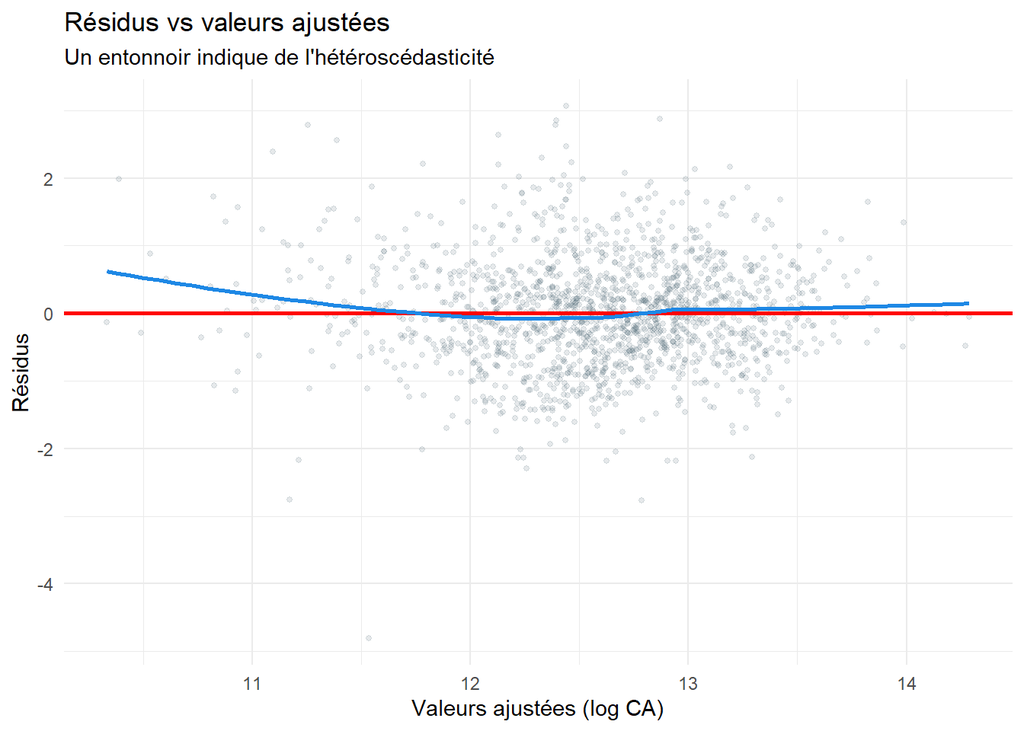

Figure — Diagnostic d’hétéroscédasticité : résidus vs valeurs ajustées

```r
tibble(
  fitted    = fitted(modele_test),
  residuals = residuals(modele_test)
) %>%
  ggplot(aes(x = fitted, y = residuals)) +
  geom_point(alpha = .15, size = 1, color = "#546E7A") +
  geom_hline(yintercept = 0, color = "red", linewidth = 1) +
  geom_smooth(method = "loess", color = "#1E88E5", se = FALSE, linewidth = 1) +
  labs(x = "Valeurs ajustées (log CA)",
       y = "Résidus",
       title = "Résidus vs valeurs ajustées",
       subtitle = "Un entonnoir indique de l'hétéroscédasticité") +
  theme_minimal()
```

# Graphiques exploratoires

## Distributions des variables clés

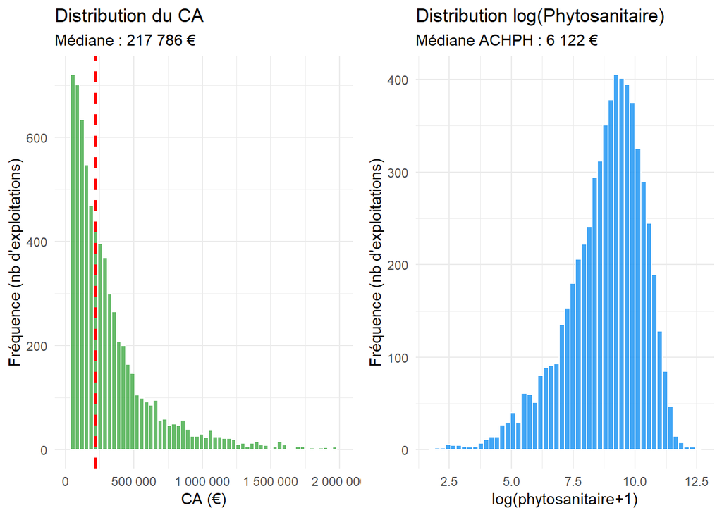

Figure — Distributions de CHAFF et ACHPH (log)

```r
p1 <- ggplot(Rica_clean, aes(x = CHAFF)) +
  geom_histogram(bins=60, fill="#4CAF50", color="white", alpha=.85) +
  geom_vline(xintercept=median(Rica_clean$CHAFF), color="red",
               linetype="dashed", linewidth=1) +
  scale_x_continuous(labels=label_comma(big.mark=" "), limits = c(20000, 2000000)) +
  labs(x="CA (€)", y="Fréquence (nb d'exploitations)", title="Distribution du CA",
         subtitle=paste0("Médiane : ",
           format(round(median(Rica_clean$CHAFF)), big.mark=" "), " €")) +
  theme_minimal()

p2 <- ggplot(filter(Rica_clean, ACHPH > 0), aes(x = log_ACHPH)) +
  geom_histogram(bins=50, fill="#2196F3", color="white", alpha=.85) +
  labs(x="log(phytosanitaire+1)", y="Fréquence (nb d'exploitations)", title="Distribution log(Phytosanitaire)",
         subtitle=paste0("Médiane ACHPH : ",
           format(round(median(Rica_clean$ACHPH)), big.mark=" "), " €")) +
  theme_minimal()

grid.arrange(p1, p2, ncol=2)
```

CA médian = 217 786 euros, Le prix médian de l’utilisation des produits phytosanitaire = 6 122 euros, l’utilisation de ses derniers representent environ 3% du chiffre d’affaire des exploitations. C’est une charge importante.

## Relation phytosanitaires / CA (log-log)

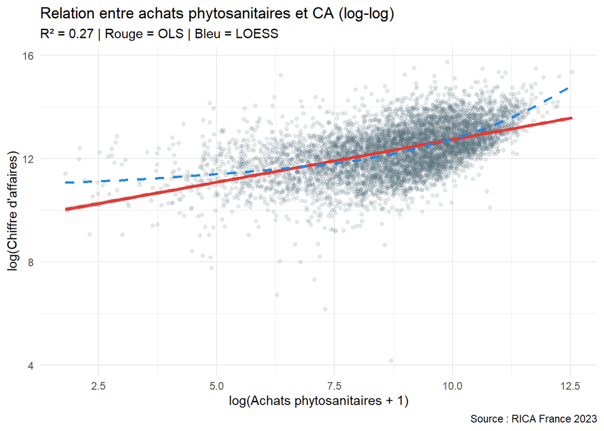

Figure — Relation ACHPH / CHAFF (log-log)

```r
Rica_clean %>% filter(ACHPH > 0) %>%
  ggplot(aes(x=log_ACHPH, y=log_CHAFF)) +
  geom_point(alpha=.15, size=1.2, color="#546E7A") +
  geom_smooth(method="lm",    color="#E53935", linewidth=1.3, se=TRUE) +
  geom_smooth(method="loess", color="#1E88E5", linewidth=1,
              linetype="dashed", se=FALSE) +
  labs(x="log(Achats phytosanitaires + 1)", y="log(Chiffre d'affaires)",
       title="Relation entre achats phytosanitaires et CA (log-log)",
       subtitle=paste0("R² = ",
         round(cor(filter(Rica_clean,ACHPH>0)$log_ACHPH,
                   filter(Rica_clean,ACHPH>0)$log_CHAFF)^2, 2),
         " | Rouge = OLS | Bleu = LOESS"),
       caption="Source : RICA France 2023") +
  theme_minimal()
```

## Relation phytosanitaires / CA (log-log) au carré

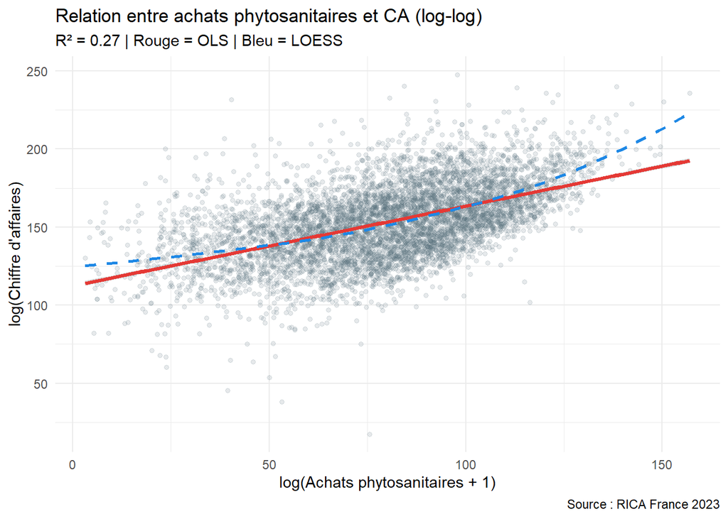

Figure — Relation ACHPH / CHAFF (log-log)

```r
Rica_clean %>% filter(ACHPH > 0) %>%
  ggplot(aes(x=log_ACHPH^2, y=log_CHAFF^2)) +
  geom_point(alpha=.15, size=1.2, color="#546E7A") +
  geom_smooth(method="lm",    color="#E53935", linewidth=1.3, se=TRUE) +
  geom_smooth(method="loess", color="#1E88E5", linewidth=1,
              linetype="dashed", se=FALSE) +
  labs(x="log(Achats phytosanitaires + 1)", y="log(Chiffre d'affaires)",
       title="Relation entre achats phytosanitaires et CA (log-log)",
       subtitle=paste0("R² = ",
         round(cor(filter(Rica_clean,ACHPH>0)$log_ACHPH,
                   filter(Rica_clean,ACHPH>0)$log_CHAFF)^2, 2),
         " | Rouge = OLS | Bleu = LOESS"),
       caption="Source : RICA France 2023") +
  theme_minimal()
```

## Relation normalisée par hectare (après fusion)

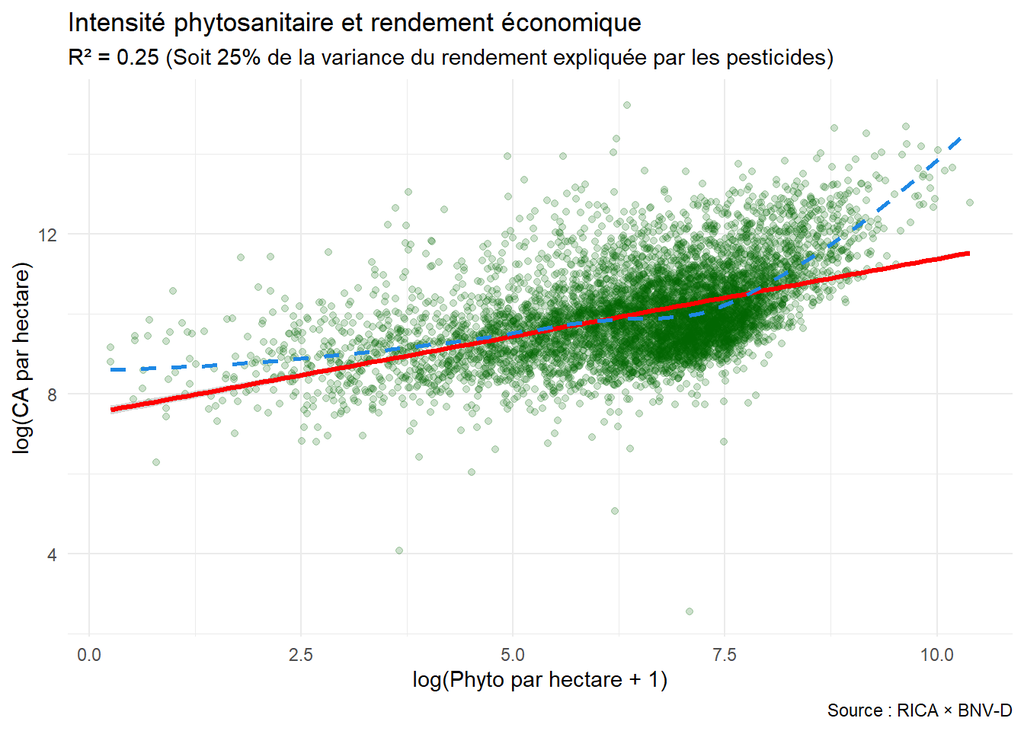

Figure — Intensité phyto vs rendement économique (€/ha)

```r
Rica_merged %>% filter(ACHPH > 0) %>%
  ggplot(aes(x = log_phyto_ha, y = log_ca_ha)) +
  geom_point(alpha = 0.2, color = "darkgreen") +
  geom_smooth(method = "lm", color = "red", linewidth = 1.2) +
  geom_smooth(method = "loess", color = "#1E88E5", linetype = "dashed",
              linewidth = 1, se = FALSE) +
labs(
  title = "Intensité phytosanitaire et rendement économique",
  subtitle = paste0(
    "R² = ",
    round(cor(filter(Rica_merged, ACHPH > 0)$log_phyto_ha,
              filter(Rica_merged, ACHPH > 0)$log_ca_ha)^2, 2),
    " (Soit ",
    round(cor(filter(Rica_merged, ACHPH > 0)$log_phyto_ha,
              filter(Rica_merged, ACHPH > 0)$log_ca_ha)^2 * 100, 0),
    "% de la variance du rendement expliquée par les pesticides)"
  ),
  x = "log(Phyto par hectare + 1)",
  y = "log(CA par hectare)",
  caption = "Source : RICA × BNV-D"
) +
  theme_minimal()
```

## Matrice de corrélation

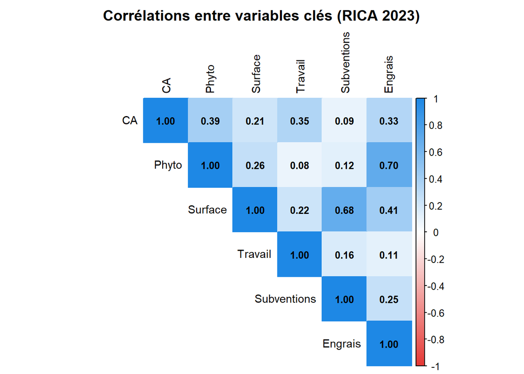

Figure — Matrice de corrélation (variables log)

```r
vars_c <- c("log_CHAFF","log_ACHPH","log_SUTOT","log_UTANS","log_SUBEX","log_CHREN")
labs_c <- c("CA","Phyto","Surface","Travail","Subventions","Engrais")
cm <- cor(Rica_clean[, vars_c], use="pairwise.complete.obs")
rownames(cm) <- colnames(cm) <- labs_c
corrplot(cm, method="color", type="upper", tl.cex=.9, tl.col="black",
         addCoef.col="black", number.cex=.8,
         col=colorRampPalette(c("#E53935","white","#1E88E5"))(200),
         title="Corrélations entre variables clés (RICA 2023)", mar=c(0,0,2,0))
```

## Comparaison graphique des modèles (échantillon commun)

```r
Rica_commun <- Rica_merged %>%
  filter(ACHPH > 0, !is.na(log_pression_reg)) %>%
  mutate(log_ACHPH2 = log_ACHPH^2)

m1_c <- lm(log_CHAFF ~ log_ACHPH + log_SUTOT + log_UTANS +
             log_SUBEX + log_CHREN,
           data = Rica_commun)

m2_c <- lm(log_CHAFF ~ log_ACHPH + log_SUTOT + log_UTANS +
             log_SUBEX + log_CHREN + REGIO_f,
           data = Rica_commun)

m3_c <- lm(log_ca_ha ~ log_phyto_ha + log_UTANS + log_SUBEX +
             log_CHREN + CODE_REGION,
           data = Rica_commun)

# Modèle 4 : terme quadratique log(ACHPH)² — relation non-linéaire
m4_c <- lm(log_CHAFF ~ log_ACHPH + log_ACHPH2 + log_SUTOT +
             log_UTANS + log_SUBEX + log_CHREN + REGIO_f,
           data = Rica_commun)
```

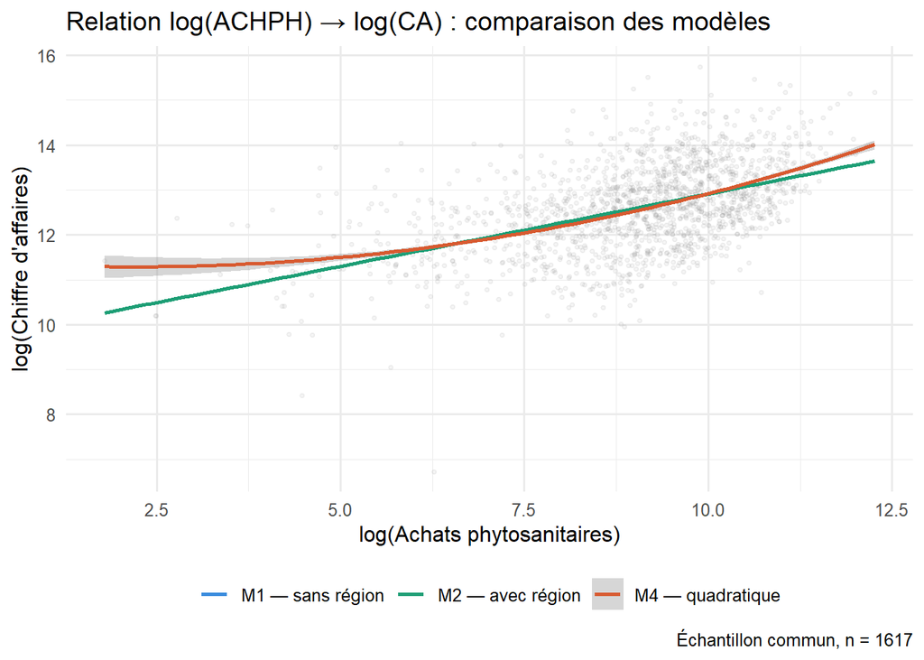

```r
Rica_commun %>%
  mutate(
    fit_m1 = fitted(m1_c),
    fit_m2 = fitted(m2_c),
    fit_m4 = fitted(m4_c)
  ) %>%
  ggplot(aes(x = log_ACHPH)) +
  geom_point(aes(y = log_CHAFF), alpha = 0.08, size = 0.8, color = "gray50") +
  geom_smooth(aes(y = fit_m1, color = "M1 — sans région"),
              method = "lm", se = FALSE, linewidth = 0.9) +
  geom_smooth(aes(y = fit_m2, color = "M2 — avec région"),
              method = "lm", se = FALSE, linewidth = 0.9) +
  geom_smooth(aes(y = fit_m4, color = "M4 — quadratique"),
              method = "lm", formula = y ~ x + I(x^2), se = TRUE, linewidth = 0.9) +
  scale_color_manual(values = c(
    "M1 — sans région" = "#378ADD",
    "M2 — avec région" = "#1D9E75",
    "M4 — quadratique" = "#D85A30"
  )) +
  labs(
    title   = "Relation log(ACHPH) → log(CA) : comparaison des modèles",
    x       = "log(Achats phytosanitaires)",
    y       = "log(Chiffre d'affaires)",
    color   = NULL,
    caption = paste0("Échantillon commun, n = ", nrow(Rica_commun))
  ) +
  theme_minimal(base_size = 12) +
  theme(legend.position = "bottom")
```

## Évolution des ventes (2013–2023)

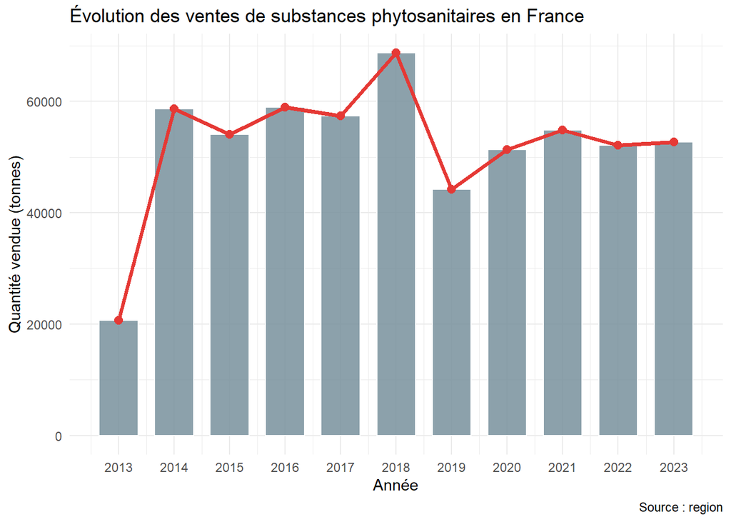

Figure — Évolution des ventes nationales

```r
region %>%
  group_by(ANNEE) %>%
  summarise(tonnes = sum(QUANTITE, na.rm=TRUE)/1000) %>%
  ggplot(aes(x=ANNEE, y=tonnes)) +
  geom_col(fill="#78909C", alpha=.85, color="white", width=.7) +
  geom_line(color="#E53935", linewidth=1.4) +
  geom_point(color="#E53935", size=2.5) +
  scale_x_continuous(breaks=2013:2023) +
  labs(x="Année", y="Quantité vendue (tonnes)",
       title="Évolution des ventes de substances phytosanitaires en France",
       caption="Source : region") +
  theme_minimal()
```

## Par type de substance et par région (2023)

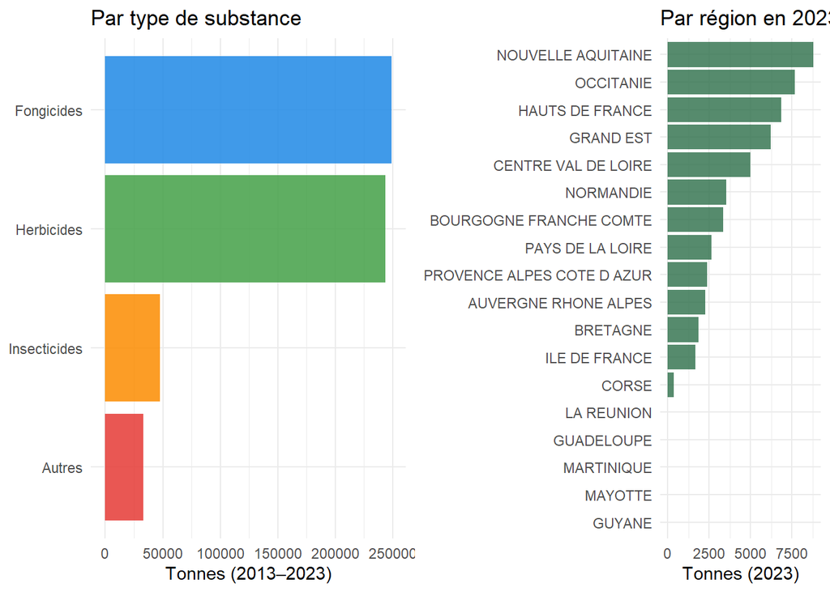

Figure — Substances et régions

```r
p_fonc <- region %>%
  group_by(FONCTION_clean) %>%
  summarise(total = sum(QUANTITE, na.rm=TRUE)/1000) %>%
  ggplot(aes(x=reorder(FONCTION_clean, total), y=total, fill=FONCTION_clean)) +
  geom_col(show.legend=FALSE, alpha=.85) +
  coord_flip() +
  scale_fill_manual(values=c("#E53935","#1E88E5","#43A047","#FB8C00")) +
  labs(x=NULL, y="Tonnes (2013–2023)", title="Par type de substance") +
  theme_minimal()

p_reg <- region %>%
  filter(ANNEE==2023, NOM_REGION != "INDETERMINE") %>%
  group_by(NOM_REGION) %>%
  summarise(total = sum(QUANTITE, na.rm=TRUE)/1000) %>%
  ggplot(aes(x=reorder(NOM_REGION, total), y=total)) +
  geom_col(fill="#2c6e49", alpha=.8) +
  coord_flip() +
  labs(x=NULL, y="Tonnes (2023)", title="Par région en 2023") +
  theme_minimal()

grid.arrange(p_fonc, p_reg, ncol=2)
```

# Régression linéaire (MCO)

## Équation opérationnelle a estimée

$$\ln(CHAFF_i) = \alpha_0
+ \underbrace{\beta_1 \ln(ACHPH_i)}_{\text{phytosanitaires}}
+ \underbrace{\beta_2 \ln(SUTOT_i)}_{\text{surface}}
+ \underbrace{\beta_3 \ln(UTANS_i)}_{\text{travail}}
+ \underbrace{\beta_4 \ln(SUBEX_i+1)}_{\text{subventions}}
+ \underbrace{\beta_5 \ln(CHREN_i+1)}_{\text{engrais}}
+ \underbrace{\sum_j \gamma_j \cdot \mathbf{1}[REGIO_i =
j]}_{\text{effets régionaux}}
+ \varepsilon_i$$

> **Note :** `REGIO` est traitée comme un **facteur** pour générer des indicatrices par région. L’utiliser comme variable numérique continue serait une erreur économétrique.

## Estimation

```r
Rica_ols <- Rica_clean %>% filter(ACHPH > 0)

# Modèle 1 : sans effets région
modele_1 <- lm(log_CHAFF ~ log_ACHPH + log_SUTOT + log_UTANS +
                 log_SUBEX + log_CHREN, data = Rica_ols)

# Modèle 2 : avec effets région
modele_2 <- lm(log_CHAFF ~ log_ACHPH + log_SUTOT + log_UTANS +
                 log_SUBEX + log_CHREN + REGIO_f, data = Rica_ols)

# Modèle 3 : normalisé par hectare + pression régionale (données fusionnées)
Rica_ols_merged <- Rica_merged %>% filter(ACHPH > 0, !is.na(log_pression_reg))

modele_3 <- lm(log_ca_ha ~ log_phyto_ha + log_UTANS + log_SUBEX +
                 log_CHREN + CODE_REGION, data = Rica_ols_merged)

# ── Échantillon commun : mêmes observations pour les 3 modèles (comparaison valide)
Rica_commun <- Rica_merged %>%
  filter(ACHPH > 0, !is.na(log_pression_reg)) %>%
  mutate(log_ACHPH2 = log_ACHPH^2)

m1_c <- lm(log_CHAFF ~ log_ACHPH + log_SUTOT + log_UTANS +
             log_SUBEX + log_CHREN,
           data = Rica_commun)

m2_c <- lm(log_CHAFF ~ log_ACHPH + log_SUTOT + log_UTANS +
             log_SUBEX + log_CHREN + REGIO_f,
           data = Rica_commun)

m3_c <- lm(log_ca_ha ~ log_phyto_ha + log_UTANS + log_SUBEX +
             log_CHREN + CODE_REGION,
           data = Rica_commun)

# Modèle 4 : terme quadratique log(ACHPH)² — relation non-linéaire
m4_c <- lm(log_CHAFF ~ log_ACHPH + log_ACHPH2 + log_SUTOT +
             log_UTANS + log_SUBEX + log_CHREN + REGIO_f,
           data = Rica_commun)

cat("N commun :", nrow(Rica_commun), "\n")
```

```
## N commun : 1617
```

## Résultats — Modèle 2 (avec effets fixes régionaux)

```r
tidy(modele_2) %>%
  # On retire l'affichage des 80 régions pour la lisibilité
  filter(!str_detect(term, "REGIO")) %>%
  mutate(
    term = recode(term,
      "(Intercept)" = "Constante (Référence)",
      "log_ACHPH"   = "log(ACHPH) — Phytosanitaires",
      "log_SUTOT"   = "log(SUTOT) — Surface (SAU)",
      "log_UTANS"   = "log(UTANS) — Travail (UTH)",
      "log_SUBEX"   = "log(SUBEX+1) — Subventions",
      "log_CHREN"   = "log(CHREN+1) — Engrais"),

    Sig. = case_when(
      p.value < .001 ~ "***",
      p.value < .01  ~ "**",
      p.value < .05  ~ "*",
      TRUE ~ ""
    ),
    across(c(estimate, std.error, statistic), ~round(., 4)),
    p.value = round(p.value, 4)
  ) %>%
  rename(Variable=term, Coefficient=estimate,
         `Err. std.`=std.error, t=statistic, `p-value`=p.value) %>%
  kable(caption = paste0(
    "Tableau — Résultats du Modèle avec Effets Fixes Régionaux | N = ",
    nrow(Rica_ols), " | R² = ", round(summary(modele_2)$r.squared, 3))) %>%
  kable_styling(bootstrap_options=c("striped","hover"))
```

Tableau — Résultats du Modèle avec Effets Fixes Régionaux | N = 6117 | R² = 0.438

| Variable | Coefficient | Err. std. | t | p-value | Sig. |
| --- | --- | --- | --- | --- | --- |
| Constante (Référence) | 8.7270 | 0.0949 | 91.9538 | 0.0000 | *** |
| log(ACHPH) — Phytosanitaires | 0.2727 | 0.0079 | 34.6911 | 0.0000 | *** |
| log(SUTOT) — Surface (SAU) | -0.0141 | 0.0178 | -0.7925 | 0.4281 |  |
| log(UTANS) — Travail (UTH) | 1.0743 | 0.0380 | 28.2841 | 0.0000 | *** |
| log(SUBEX+1) — Subventions | 0.0025 | 0.0049 | 0.5216 | 0.6019 |  |
| log(CHREN+1) — Engrais | 0.0252 | 0.0046 | 5.4478 | 0.0000 | *** |

```r
# On utilise tidy pour récupérer les résultats du modèle 3
tidy(m3_c) %>%
  # On cache les 80 régions pour que le tableau reste lisible
  filter(!str_detect(term, "REGIO")) %>%
  mutate(
    term = recode(term,
      "(Intercept)"      = "Constante (Référence)",
      "log_ACHPH"        = "log(ACHPH) — Effet linéaire",
      "I(log_ACHPH^2)"   = "log(ACHPH)² — Effet quadratique (Courbe)",
      "log_SUTOT"        = "log(SUTOT) — Surface (SAU)",
      "log_UTANS"        = "log(UTANS) — Travail (UTH)",
      "log_SUBEX"        = "log(SUBEX+1) — Subventions",
      "log_CHREN"        = "log(CHREN+1) — Engrais"),

    # Calcul des étoiles de significativité
    Sig. = case_when(
      p.value < .001 ~ "***",
      p.value < .01  ~ "**",
      p.value < .05  ~ "*",
      TRUE ~ ""
    ),
    # Arrondi des coefficients et p-values
    across(c(estimate, std.error, statistic), ~round(., 4)),
    p.value = round(p.value, 4)
  ) %>%
  rename(Variable=term, Coefficient=estimate,
         `Err. std.`=std.error, t=statistic, `p-value`=p.value) %>%
  kable(caption = paste0(
    "Tableau — MCO Modèle 3 (CA par hectare et effets régionaux) | N = ",
    nrow(Rica_commun), " | R² = ", round(summary(m3_c)$r.squared, 3))) %>%
  kable_styling(bootstrap_options=c("striped","hover")) %>%
  # On surligne la ligne des pesticides
  row_spec(2, bold=TRUE, background="#e3f2fd")
```

Tableau — MCO Modèle 3 (CA par hectare et effets régionaux) | N = 1617 | R² = 0.46

| Variable | Coefficient | Err. std. | t | p-value | Sig. |
| --- | --- | --- | --- | --- | --- |
| Constante (Référence) | 7.9418 | 0.1732 | 45.8561 | 0 | *** |
| log_phyto_ha | 0.4400 | 0.0181 | 24.3012 | 0 | *** |
| log(UTANS) — Travail (UTH) | 0.7292 | 0.0828 | 8.8100 | 0 | *** |
| log(SUBEX+1) — Subventions | -0.1131 | 0.0077 | -14.7363 | 0 | *** |
| log(CHREN+1) — Engrais | -0.0734 | 0.0094 | -7.7735 | 0 | *** |

```r
tidy(modele_1) %>%
  mutate(
    term = recode(term,
      "(Intercept)" = "Constante",
      "log_ACHPH"   = "log(ACHPH) — phytosanitaires",
      "log_SUTOT"   = "log(SUTOT) — surface SAU",
      "log_UTANS"   = "log(UTANS) — travail UTH",
      "log_SUBEX"   = "log(SUBEX+1) — subventions",
      "log_CHREN"   = "log(CHREN+1) — engrais",
      "log_REGIO"   = "log(REGIO_f) — region"),

    Sig. = case_when(p.value<.001~"***", p.value<.01~"**",
                     p.value<.05~"*", TRUE~""),
    across(c(estimate, std.error, statistic), ~round(., 4)),
    p.value = round(p.value, 4)
  ) %>%
  rename(Variable=term, Coefficient=estimate,
         `Err. std.`=std.error, t=statistic, `p-value`=p.value) %>%
  kable(caption=paste0(
    "Tableau — MCO Modèle 1 (sans effets région) | N = ",
    nrow(Rica_ols), " | R² = ", round(summary(modele_1)$r.squared, 3),
    " | *** p<0.001")) %>%
  kable_styling(bootstrap_options=c("striped","hover")) %>%
  row_spec(2, bold=TRUE, background="#fff3cd")
```

Tableau — MCO Modèle 1 (sans effets région) | N = 6117 | R² = 0.37 | *** p<0.001

| Variable | Coefficient | Err. std. | t | p-value | Sig. |
| --- | --- | --- | --- | --- | --- |
| Constante | 8.6601 | 0.0694 | 124.8125 | 0.0000 | *** |
| log(ACHPH) — phytosanitaires | 0.2781 | 0.0078 | 35.8736 | 0.0000 | *** |
| log(SUTOT) — surface SAU | 0.0766 | 0.0164 | 4.6856 | 0.0000 | *** |
| log(UTANS) — travail UTH | 1.1506 | 0.0395 | 29.1010 | 0.0000 | *** |
| log(SUBEX+1) — subventions | -0.0149 | 0.0047 | -3.1552 | 0.0016 | ** |
| log(CHREN+1) — engrais | 0.0223 | 0.0048 | 4.6737 | 0.0000 | *** |

## Tableau de synthèse — Comparaison des 4 modèles (échantillon commun)

Les modèles 1, 2 et 3 sont ici ré-estimés sur le **même échantillon** (`Rica_commun`, n = exploitations fusionnées avec ACHPH > 0) afin de rendre la comparaison des R² valide. Le modèle 4 introduit un terme quadratique pour tester une relation non-linéaire.

```r
# Seuil de maximisation du CA (si β₂ < 0 → rendements décroissants)
beta1 <- coef(m4_c)["log_ACHPH"]
beta2 <- coef(m4_c)["log_ACHPH2"]
if (!is.na(beta2) && beta2 < 0) {
  seuil_log   <- -beta1 / (2 * beta2)
  seuil_euros <- exp(seuil_log)
  cat("Seuil de maximisation du CA :", round(seuil_euros), "€ d'achats phyto\n")
}

data.frame(
  Modèle    = c("M1 — sans région",
                "M2 — avec effets région",
                "M3 — €/ha + région",
                "M4 — quadratique"),
  N         = rep(nrow(Rica_commun), 4),
  R2        = round(c(summary(m1_c)$r.squared,
                      summary(m2_c)$r.squared,
                      summary(m3_c)$r.squared,
                      summary(m4_c)$r.squared), 4),
  R2_adj    = round(c(summary(m1_c)$adj.r.squared,
                      summary(m2_c)$adj.r.squared,
                      summary(m3_c)$adj.r.squared,
                      summary(m4_c)$adj.r.squared), 4),
  AIC       = round(c(AIC(m1_c), AIC(m2_c), AIC(m3_c), AIC(m4_c)), 1),
  beta_ACHPH = round(c(coef(m1_c)["log_ACHPH"],
                       coef(m2_c)["log_ACHPH"],
                       NA,
                       coef(m4_c)["log_ACHPH"]), 4)
) %>%
  kable(caption = paste0("Tableau de synthèse — 4 modèles sur échantillon commun | N = ",
                         nrow(Rica_commun)),
        col.names = c("Modèle", "N", "R²", "R² ajusté", "AIC", "β log(ACHPH)")) %>%
  kable_styling(bootstrap_options = c("striped", "hover")) %>%
  row_spec(which.max(c(summary(m1_c)$adj.r.squared,
                       summary(m2_c)$adj.r.squared,
                       summary(m3_c)$adj.r.squared,
                       summary(m4_c)$adj.r.squared)),
           bold = TRUE, background = "#d4edda")
```

Tableau de synthèse — 4 modèles sur échantillon commun | N = 1617

| Modèle | N | R² | R² ajusté | AIC | β log(ACHPH) |
| --- | --- | --- | --- | --- | --- |
| M1 — sans région | 1617 | 0.3298 | 0.3277 | 3864.2 | 0.3126 |
| M2 — avec effets région | 1617 | 0.4256 | 0.4220 | 3624.8 | 0.3464 |
| M3 — €/ha + région | 1617 | 0.4598 | 0.4568 | 4064.7 | NA |
| M4 — quadratique | 1617 | 0.4537 | 0.4500 | 3545.5 | -0.4418 |

## Interprétation des paramètres

**β₁ = 0.278** : une hausse de 1 % des achats phytosanitaires est associée, *toutes choses égales*, à +**0.28 %** de CA (élasticité). Confirme l’hypothèse de complémentarité. L’élasticité < 1 indique des rendements décroissants.

**β₂ = 0.077** : effet surface positif modéré, reflétant l’hétérogénéité des systèmes de production.

**β₃ = 1.151** : facteur le plus élastique (+1.15 % de CA pour +1 % de travail).

**β₄ = -0.015** : effet légèrement négatif — les aides PAC compensent des exploitations moins productives sans stimuler le CA marchand.

**β₅ = 0.022** : complémentarité engrais–rendement confirmée.

## Variables manquantes et proxies

Tableau — Variables manquantes, proxies et sources

| Variable idéale | Proxy utilisé | Source si disponible |
| --- | --- | --- |
| Prix des produits | — | FranceAgriMer |
| Rendements physiques | CHAFF (proxy imparfait) | Teruti-Lucas |
| Données météo | Effets fixes région | Météo-France |
| Pression parasitaire | Volumes BNV-D régionaux (après fusion) | BNV-D (déjà intégrée) |
| Agriculture biologique | — | Agence Bio |
| Capital équipements | — | RICA investissements |

## Limites du modèle

- **Hétéroscédasticité** : détectée par le test de Breusch-Pagan → erreurs robustes de White (`vcovHC`, HC3) calculées et comparées aux erreurs classiques (tableau de comparaison ci-dessus).
- **Variables omises** : prix des produits agricoles, météo, rendements physiques expliquent la variance résiduelle (R² = 0.37).

### Biais de sélection (sur n = 1617)

```r
Rica_clean %>%
  mutate(dans_commun = IDNUM %in% Rica_commun$IDNUM) %>%
  group_by(dans_commun) %>%
  summarise(
    n          = n(),
    CA_median  = round(median(CHAFF, na.rm = TRUE), 0),
    SAU_median = round(median(SUTOT, na.rm = TRUE), 1),
    UTH_median = round(median(UTANS, na.rm = TRUE), 2)
  ) %>%
  mutate(Groupe = ifelse(dans_commun, "Dans l'échantillon commun", "Exclu")) %>%
  select(Groupe, n, CA_median, SAU_median, UTH_median) %>%
  kable(caption = "Biais de sélection — Comparaison échantillon commun vs exclus",
        col.names = c("Groupe", "N", "CA médian (€)", "SAU médiane (ha)", "UTH médian"),
        format.args = list(big.mark = " ")) %>%
  kable_styling(bootstrap_options = c("striped", "hover"), font_size = 11)
```

Biais de sélection — Comparaison échantillon commun vs exclus

| Groupe | N | CA médian (€) | SAU médiane (ha) | UTH médian |
| --- | --- | --- | --- | --- |
| Exclu | 5 597 | 196 591 | 13 | 1 |
| Dans l’échantillon commun | 1 617 | 295 057 | 14 | 1 |

Un modèle de Heckman permettrait de corriger ce biais en modélisant conjointement la décision d’utiliser des pesticides et le niveau de CA.

### Endogénéité de ACHPH

ACHPH est probablement endogène : les exploitations aux cultures plus risquées achètent davantage de phytos *et* réalisent un CA plus élevé indépendamment des pesticides. L’équation ci-dessous régresse log(ACHPH) sur les déterminants exogènes plausibles (« première étape »). Un instrument n’est pertinent que s’il est significatif dans cette première étape. L’endogénéité n’est donc pas corrigée ici : les coefficients sont à lire comme des associations et non comme des effets causaux.

```r
# Équation de première étape
m_first_stage <- lm(
  log_ACHPH ~ log_SUTOT + log_UTANS + log_SUBEX + log_CHREN +
               log_pression_reg + REGIO_f,
  data = Rica_commun
)

tidy(m_first_stage) %>%
  filter(!grepl("REGIO", term)) %>%
  mutate(
    term = recode(term,
      "(Intercept)"    = "Constante",
      "log_SUTOT"      = "log(SUTOT) — surface",
      "log_UTANS"      = "log(UTANS) — travail",
      "log_SUBEX"      = "log(SUBEX+1) — subventions",
      "log_CHREN"      = "log(CHREN+1) — engrais",
      "log_pression_reg" = "log(pression BNV-D régionale)"),
    Sig. = case_when(p.value < .001 ~ "***", p.value < .01 ~ "**",
                     p.value < .05 ~ "*", TRUE ~ ""),
    across(c(estimate, std.error, statistic), ~round(., 4)),
    p.value = round(p.value, 4)
  ) %>%
  rename(Variable = term, Coefficient = estimate,
         `Err. std.` = std.error, t = statistic, `p-value` = p.value) %>%
  kable(caption = paste0(
    "Équation de première étape — Déterminants de log(ACHPH) | R² = ",
    round(summary(m_first_stage)$r.squared, 3),
    " (effets région masqués pour lisibilité)")) %>%
  kable_styling(bootstrap_options = c("striped", "hover"), font_size = 11)
```

Équation de première étape — Déterminants de log(ACHPH) | R² = 0.419 (effets région masqués pour lisibilité)

| Variable | Coefficient | Err. std. | t | p-value | Sig. |
| --- | --- | --- | --- | --- | --- |
| Constante | 7.6033 | 1.6384 | 4.6407 | 0.0000 | *** |
| log(SUTOT) — surface | 0.5022 | 0.0494 | 10.1740 | 0.0000 | *** |
| log(UTANS) — travail | 0.1470 | 0.1125 | 1.3061 | 0.1917 |  |
| log(SUBEX+1) — subventions | -0.0043 | 0.0129 | -0.3299 | 0.7416 |  |
| log(CHREN+1) — engrais | 0.2370 | 0.0128 | 18.5746 | 0.0000 | *** |
| log(pression BNV-D régionale) | -0.1145 | 0.1187 | -0.9651 | 0.3346 |  |